# $p_A(\lambda) = |A - \lambda I_n|$ is a polynomial of degree $n$ in $\lambda$

```python
import numpy as np
import pandas as pd
import matplotlib.pyplot as plt
import seaborn as sns
import sympy as sy
%matplotlib inline
```

Some functions to plot a matrix

```python
def plot_mat(A, annot):
    n = A.shape[0]
    plt.figure(figsize=(n, n))
    sns.heatmap(A, annot=annot, annot_kws={'fontsize':16, 'fontweight':'bold'}, fmt = '', xticklabels=False, yticklabels=False,
               cbar=False, square=True)

def get_annot(A):
    annot = A.astype('str')
    diag = np.diag(annot)
    annot[np.diag_indices_from(annot)] = [(a * (int(a) != 0)) + ' - $\lambda$' for a in diag]
    return annot

def submat(A, i, j):
    A1 = np.concatenate([A[:i, :j], A[:i, (j+1):]], axis=-1)
    A2 = np.concatenate([A[(i+1):, :j], A[(i+1):, (j+1):]], axis=-1)
    return np.concatenate([A1, A2], axis=0)

def submat_sym(A, i, j):
    A1 = A[:i, :j].row_join(A[:i, (j+1):])
    A2 = A[(i+1):, :j].row_join(A[(i+1):, (j+1):])
    return A1.col_join(A2)
```

We would like to prove that the characteristic polynomial of a matrix has order $n$.

Let us first note that we are concerned with $n \times n$ matrices for which:

- There are no more than $n$ entries of the form $a - \lambda$ for a constant $a$
- All other entries constant.
- The $a - \lambda$ elements appear no more than once per column and per row.

An $n \times n$ matrix such as the following random $5 x 5$ matrix with $\lambda$ subtracted from its diagonal entries, whose determinant is obtained to find its eigenvalues is such an example.

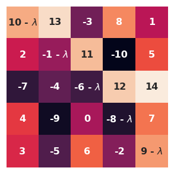

```python
n = 5
np.random.seed(27)
A = np.random.permutation(np.arange(-10, 15)).reshape((5, 5))
annot = get_annot(A)
plot_mat(A, annot)
```

```python
A_sym = sy.Matrix(A) - sy.Symbol('\lambda') * sy.eye(5)
A_sym
```

$\displaystyle \left[\begin{matrix}10 - \lambda & 13 & -3 & 8 & 1\\2 & - \lambda - 1 & 11 & -10 & 5\\-7 & -4 & - \lambda - 6 & 12 & 14\\4 & -9 & 0 & - \lambda - 8 & 7\\3 & -5 & 6 & -2 & 9 - \lambda\end{matrix}\right]$

```python
sy.det(A_sym)
```

$\displaystyle - \lambda^{5} + 4 \lambda^{4} + 306 \lambda^{3} - 3679 \lambda^{2} + 5942 \lambda + 192420$

The submatrix obtaining by omitting row $i$, column $j$ is another example. When $i = j$, there are exactly $n=4$ such entries.

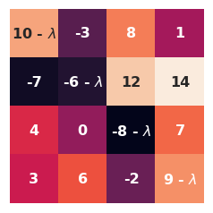

```python
plot_mat(submat(A, 1, 1), submat(annot, 1, 1))
```

When $i \neq j$ there are strictly fewer than $n=4$ entries.

```python
submat_sym(A_sym, 1, 1)
```

$\displaystyle \left[\begin{matrix}10 - \lambda & -3 & 8 & 1\\-7 & - \lambda - 6 & 12 & 14\\4 & 0 & - \lambda - 8 & 7\\3 & 6 & -2 & 9 - \lambda\end{matrix}\right]$

```python
sy.det(submat_sym(A_sym, 1, 1))
```

$\displaystyle \lambda^{4} - 5 \lambda^{3} - 254 \lambda^{2} + 183 \lambda + 22302$

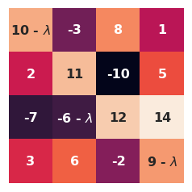

```python
plot_mat(submat(A, 3, 1), submat(annot, 3, 1))
```

```python
submat_sym(A_sym, 3, 1)
```

$\displaystyle \left[\begin{matrix}10 - \lambda & -3 & 8 & 1\\2 & 11 & -10 & 5\\-7 & - \lambda - 6 & 12 & 14\\3 & 6 & -2 & 9 - \lambda\end{matrix}\right]$

```python
sy.det(submat_sym(A_sym, 3, 1))
```

$\displaystyle - 10 \lambda^{3} + 268 \lambda^{2} - 1716 \lambda + 1206$

The proof is by induction:

- First note that we will only be concerned with matrices as described above i.e. no more than one $a - \lambda$ type term for every column and row.
- We prove a more general case that for such a matrix:
  - If it has $n$ $a - \lambda$ type entries, the determinant is degree $n$ in $\lambda$.
  - If degree $n$ in $\lambda$, then coeffient of $\lambda^n$ in the polynomial is $\pm1$
  - If fewer than $n$ such entries the degree is $< n$.

**Base case**

- Note that for a $1 \times 1$ matrix which is a scalar, the determinant is degree $1$ in $\lambda$ if the scalar is of the form $a - \lambda$
- So for the base case $p_A(\lambda)$ is degree $n=1$ with coefficient $-1$ if there are $n$ such entries else it is degree $<n$.

**Induction step**